# Univariate Forecasts for extreme_heat and extreme_cold

## Time Series Decomposition with min_temp_val

Now for Time Series decomposition.

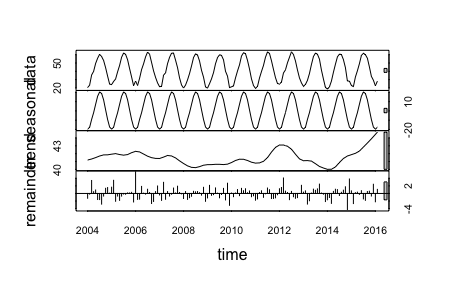

```r
decomp = stl(train, s.window="periodic")
plot(decomp)
```

As previously, our first attempt will just forecast the time series by removing seasonality, and then using the last observation to which we add back the seasonality as the next forecast value.

```r
stlfk_naive = forecast(decomp, method="naive", h=12)
summary(stlfk_naive)
```

```
Forecast method: STL +  Random walk

Model Information:
Call: rwf(y = x, h = h, drift = FALSE, level = level)

Residual sd: 2.269

Error measures:
                     ME     RMSE      MAE        MPE     MAPE      MASE       ACF1
Training set 0.04064998 2.261518 1.675095 -0.1862235 5.137839 0.8422618 -0.5119057

Forecasts:
         Point Forecast    Lo 80    Hi 80    Lo 95    Hi 95
Mar 2016       36.59956 33.70130 39.49781 32.16706 41.03205
Apr 2016       43.91371 39.81496 48.01246 37.64522 50.18220
May 2016       52.85453 47.83461 57.87445 45.17722 60.53184
Jun 2016       61.57856 55.78205 67.37506 52.71357 70.44354
Jul 2016       66.25925 59.77856 72.73994 56.34789 76.17061
Aug 2016       64.64313 57.54389 71.74237 53.78578 75.50048
Sep 2016       57.69867 50.03062 65.36673 45.97139 69.42595
Oct 2016       46.98234 38.78484 55.17983 34.44535 59.51933
Nov 2016       36.57017 27.87542 45.26493 23.27269 49.86766
Dec 2016       28.47479 19.30971 37.63987 14.45801 42.49157
Jan 2017       26.15425 16.54183 35.76666 11.45333 40.85517
Feb 2017       28.11000 18.07016 38.14984 12.75539 43.46461
```

```r
accuracy(stlfk_naive, test)
```

```
                      ME     RMSE      MAE        MPE     MAPE      MASE        ACF1 Theil's U
Training set  0.04064998 2.261518 1.675095 -0.1862235 5.137839 0.8422618 -0.51190568        NA
Test set     -2.37657891 3.067990 2.724912 -5.7553539 6.908775 1.3701247  0.02845487 0.4273305
```

Let’s try with exponential smoothing to forecast the seasonally-adjusted series.

```r
stlfk_ets = forecast(decomp, method="ets", h=12)
summary(stlfk_ets)
```

```
Forecast method: STL +  ETS(M,N,N)

Model Information:
ETS(M,N,N)

Call:
 ets(y = x, model = etsmodel, allow.multiplicative.trend = allow.multiplicative.trend)

  Smoothing parameters:
    alpha = 0.2071

  Initial states:
    l = 41.5325

  sigma:  0.0428

     AIC     AICc      BIC
900.6789 900.8479 909.6297

Error measures:
                     ME     RMSE      MAE       MPE     MAPE      MASE         ACF1
Training set 0.07537092 1.775772 1.393616 -0.145014 4.219744 0.7007299 0.0005204832

Forecasts:
         Point Forecast    Lo 80    Hi 80    Lo 95    Hi 95
Mar 2016       34.59161 32.18814 36.99508 30.91583 38.26739
Apr 2016       41.90576 39.45118 44.36035 38.15181 45.65972
May 2016       50.84658 48.34193 53.35124 47.01604 54.67713
Jun 2016       59.57061 57.01686 62.12437 55.66498 63.47624
Jul 2016       64.25130 61.64937 66.85323 60.27199 68.23061
Aug 2016       62.63518 59.98595 65.28442 58.58353 66.68684
Sep 2016       55.69073 52.99502 58.38644 51.56799 59.81346
Oct 2016       44.97439 42.23299 47.71580 40.78178 49.16701
Nov 2016       34.56223 31.77588 37.34858 30.30087 38.82358
Dec 2016       26.46684 23.63626 29.29743 22.13784 30.79585
Jan 2017       24.14630 21.27216 27.02045 19.75068 28.54193
Feb 2017       26.10205 23.18500 29.01911 21.64080 30.56331
```

```r
accuracy(stlfk_ets, test)
```

```
                      ME     RMSE      MAE        MPE     MAPE      MASE         ACF1 Theil's U
Training set  0.07537092 1.775772 1.393616 -0.1450140 4.219744 0.7007299 0.0005204832        NA
Test set     -0.36863382 1.974925 1.632535 -0.6064302 4.473935 0.8208621 0.0284548714 0.3465735
```

As a last attempt, we can also use arima on the seasonally-adjusted data.

```r
stlfk_arima = forecast(decomp, method="arima", h=12)
summary(stlfk_arima)
```

```
Forecast method: STL +  ARIMA(3,0,0) with non-zero mean

Model Information:
Series: x
ARIMA(3,0,0) with non-zero mean

Coefficients:
         ar1     ar2     ar3     mean
      0.1538  0.1968  0.1561  41.5203
s.e.  0.0827  0.0824  0.0858   0.2859

sigma^2 estimated as 3.055:  log likelihood=-286.79
AIC=583.58   AICc=584.01   BIC=598.5

Error measures:
                      ME     RMSE      MAE        MPE     MAPE      MASE        ACF1
Training set 0.004968654 1.723831 1.340291 -0.3275602 4.107519 0.6739173 0.005010114

Forecasts:
         Point Forecast    Lo 80    Hi 80    Lo 95    Hi 95
Mar 2016       33.89807 31.65799 36.13815 30.47217 37.32397
Apr 2016       40.82061 38.55420 43.08702 37.35444 44.28678
May 2016       49.72612 47.40656 52.04569 46.17866 53.27359
Jun 2016       57.94592 55.57446 60.31738 54.31908 61.57275
Jul 2016       62.48099 60.09871 64.86327 58.83760 66.12437
Aug 2016       60.73775 58.34632 63.12919 57.08037 64.39513
Sep 2016       53.66638 51.27000 56.06275 50.00144 57.33132
Oct 2016       42.88278 40.48431 45.28125 39.21464 46.55092
Nov 2016       32.41546 30.01571 34.81520 28.74536 36.08555
Dec 2016       24.27854 21.87815 26.67893 20.60746 27.94963
Jan 2017       21.93026 19.52954 24.33098 18.25868 25.60184
Feb 2017       23.86496 21.46406 26.26586 20.19311 27.53682
```

```r
accuracy(stlfk_arima, test)
```

```
                      ME     RMSE      MAE        MPE     MAPE      MASE        ACF1 Theil's U
Training set 0.004968654 1.723831 1.340291 -0.3275602 4.107519 0.6739173 0.005010114        NA
Test set     1.389346252 2.530931 1.830226  4.0391596 5.337598 0.9202636 0.147787493 0.4925082
```

R picked an ARIMA(3,0,0).

The best model for now when we consider RMSE on the Test set is the STL + ETS(M,N,N).

## Seasonal ARIMA

We first look at the auto.arima output.

```r
autofit = auto.arima(train, seasonal=TRUE)
print(autofit)
```

```
Series: train
ARIMA(3,0,0)(2,1,2)[12]

Coefficients:
         ar1     ar2     ar3     sar1     sar2     sma1    sma2
      0.1719  0.1656  0.1365  -0.0888  -0.3363  -0.7702  0.0269
s.e.  0.0901  0.0885  0.0904   0.3322   0.1174   0.3381  0.3359

sigma^2 estimated as 3.511:  log likelihood=-279.89
AIC=575.77   AICc=576.92   BIC=598.95
```

```r
autofk = forecast(autofit,h=12)
accuracy(autofk,test)
```

```
                     ME     RMSE      MAE        MPE     MAPE
Training set 0.02325838 1.747624 1.323112 -0.4383637 4.085590
Test set     1.49037834 2.498759 1.808324  4.4759926 5.210906
                  MASE        ACF1 Theil's U
Training set 0.6652793 0.006805138        NA
Test set     0.9092510 0.287423122 0.4894413
```

Let us now try with our own seasonal ARIMA. Based on the ACF PACF of the annual differentiation, we try with an ARIMA(3,0,0)(2,1,2).

```r
custfit = Arima(train, order=c(3,0,0), seasonal=c(2,1,2))
print(custfit)
```

```
Series: train
ARIMA(3,0,0)(2,1,2)[12]

Coefficients:
         ar1     ar2     ar3     sar1     sar2     sma1    sma2
      0.1719  0.1656  0.1365  -0.0888  -0.3363  -0.7702  0.0269
s.e.  0.0901  0.0885  0.0904   0.3322   0.1174   0.3381  0.3359

sigma^2 estimated as 3.511:  log likelihood=-279.89
AIC=575.77   AICc=576.92   BIC=598.95
```

```r
custfk = forecast(custfit,h=12)
accuracy(custfk,test)
```

```
                     ME     RMSE      MAE        MPE     MAPE      MASE        ACF1 Theil's U
Training set 0.02325838 1.747624 1.323112 -0.4383637 4.085590 0.6652793 0.006805138        NA
Test set     1.49037834 2.498759 1.808324  4.4759926 5.210906 0.9092510 0.287423122 0.4894413
```

### Rolling Window Evaluation

To try more model, we would like to setup a rolling window. Let us find the optimal size of that window using the STL + ETS(M,N,N) we just fitted.

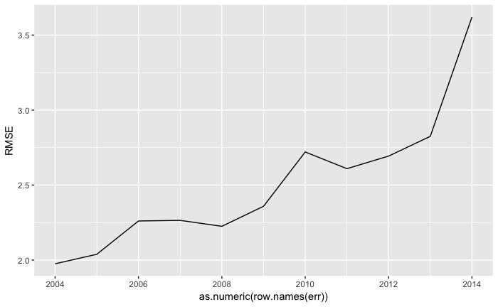

```r
library(ggplot2)
err = data.frame("RMSE" = rep(0, 2014-2004+1), row.names = seq(2004, 2014))
for (y in 2004:2014){
    model = stl(window(train, start=c(y,1)), s.window="periodic")
    rmse = accuracy(forecast(model, method="ets", h=12),test)[2,"RMSE"]
    err[as.character(y),] = rmse
}
ggplot(err)+geom_line(aes(x=as.numeric(row.names(err)), y=RMSE))
```

So we should take the entire historical data ! Let’s just check with the months in 2014 :

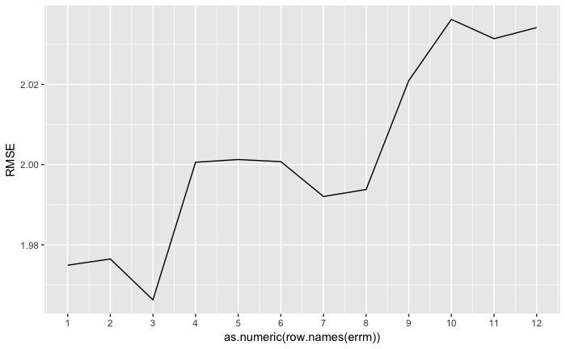

```r
errm = data.frame("RMSE" = rep(0, 12), row.names = seq(1, 12))
for (m in 1:12){
    model = stl(window(train, start=c(2004,m)), s.window="periodic")
    rmse = accuracy(forecast(model, method="ets", h=12),test)[2,"RMSE"]
    errm[as.character(m),] = rmse
}
ggplot(errm)+geom_line(aes(x=as.numeric(row.names(errm)), y=RMSE))+scale_x_continuous(breaks=seq(1,12))
```

We actually should start at 2004-03 (which makes sense since we predict starting mars). We will thus use all the dataset except the 2 first months. So no need for a rolling window.

Creation of the needed forecast : from March 2017 to March 2018 (we will only use from March 2017 to July 2017).

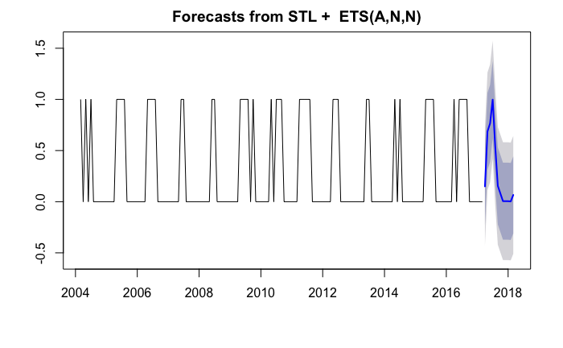

```r
train_final = window(sextreme_heat, start=c(2004,3), end=c(2017,3))
model = stl(train_final, s.window="periodic")
yearly_forecast = forecast(model, method="ets", h=12)
plot(yearly_forecast)
```

# extreme_cold

### Stationarity and integration of the extreme_cold

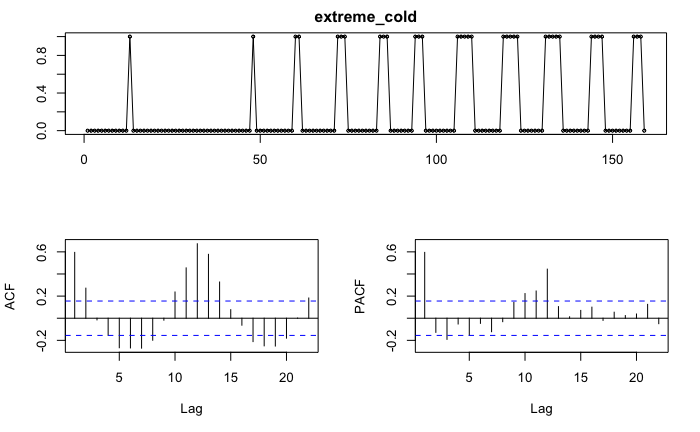

```r
library(forecast)
tsdisplay(extreme_cold,main="extreme_cold")
```

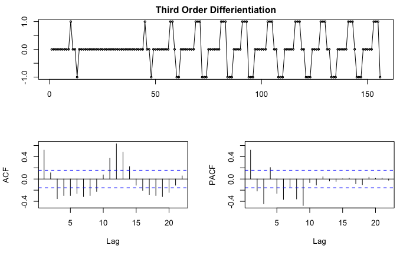

```r
tsdisplay(diff(extreme_cold, 3), main="Third Order Differientiation")
```

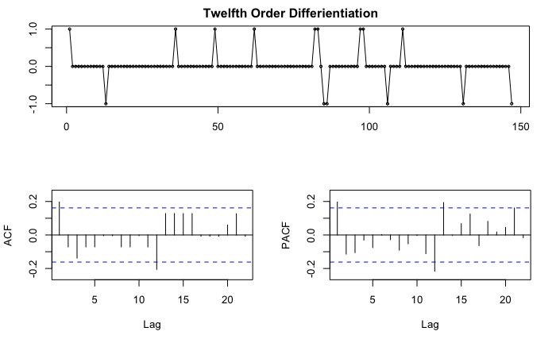

```r
tsdisplay(diff(extreme_cold, 12), main="Twelfth Order Differientiation")
```

As previously, we need to do a 12th order differenciation in order to remove the seasonality. We notice that extreme_cold also ressembles a white noise.

### Models evaluation

Let us convert data to a time series

```r
sextreme_cold = ts(extreme_cold, start = c(2004, 1), frequency=12)
train = window(sextreme_cold, start = c(2004, 1), end = c(2016, 2))
test = window(sextreme_cold, start = c(2016,3), end = c(2017, 2))
```

## Simple Snaive

We first start with a simple seasonal naive process (ie. repetition of the last temporality).

```r
snaive = snaive(train, h = 12)
accuracy(snaive, test)
```

```
                     ME    RMSE       MAE  MPE MAPE MASE      ACF1 Theil's U
Training set 0.02985075 0.32323 0.1044776 -Inf  Inf    1 0.2096132        NA
Test set     0.00000000 0.00000 0.0000000    0    0    0       NaN         0
```

We have an exact forecast !!

Now for Time Series decomposition.

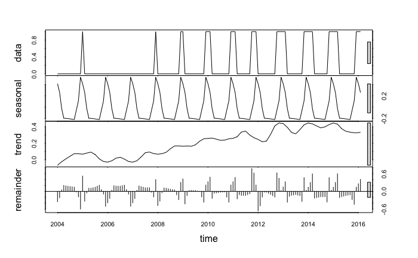

```r
decomp = stl(train, s.window="periodic")
plot(decomp)
```

As previously, our first attempt will just forecast the time series by removing seasonality, and then using the last observation to which we add back the seasonality as the next forecast value.

```r
stlfk_naive = forecast(decomp, method="naive", h=12)
summary(stlfk_naive)
```

```
Forecast method: STL +  Random walk

Model Information:
Call: rwf(y = x, h = h, drift = FALSE, level = level)

Residual sd: 0.3205

Error measures:
                      ME     RMSE       MAE MPE MAPE     MASE       ACF1
Training set 0.007968842 0.319519 0.1938784 NaN  Inf 1.855694 -0.2656563

Forecasts:
         Point Forecast       Lo 80    Hi 80       Lo 95    Hi 95
Mar 2016      0.7142187  0.30473858 1.123699  0.08797292 1.340464
Apr 2016      0.5457466 -0.03334569 1.124839 -0.33989862 1.431392
May 2016      0.5439409 -0.16529939 1.253181 -0.54074852 1.628630
Jun 2016      0.5389395 -0.28002066 1.357900 -0.71355198 1.791431
Jul 2016      0.5339381 -0.38168721 1.449563 -0.86638997 1.934266
Aug 2016      0.5283989 -0.47461833 1.531416 -1.00558360 2.062381
Sep 2016      0.5228598 -0.56052270 1.606242 -1.13403073 2.179750
Oct 2016      0.6875793 -0.47060526 1.845764 -1.08371114 2.458870
Nov 2016      0.8522986 -0.37614165 2.080739 -1.02643863 2.731036
Dec 2016      1.2688871 -0.02600263 2.563777 -0.71147584 3.249250
Jan 2017      1.1554821 -0.20260968 2.513574 -0.92154004 3.232504
Feb 2017      1.0000000 -0.41848061 2.418481 -1.16937888 3.169379
```

```r
accuracy(stlfk_naive, test)
```

```
                       ME      RMSE       MAE  MPE MAPE     MASE       ACF1 Theil's U
Training set  0.007968842 0.3195190 0.1938784  NaN  Inf 1.855694 -0.2656563        NA
Test set     -0.407690793 0.5081969 0.4553210 -Inf  Inf 4.358073  0.1986717         0
```

Let’s try with exponential smoothing to forecast the seasonally-adjusted series.

```r
stlfk_ets = forecast(decomp, method="ets", h=12)
summary(stlfk_ets)
```

```
Forecast method: STL +  ETS(A,N,N)

Model Information:
ETS(A,N,N)

Call:
 ets(y = x, model = etsmodel, allow.multiplicative.trend = allow.multiplicative.trend)

  Smoothing parameters:
    alpha = 0.4696

  Initial states:
    l = -0.2263

  sigma:  0.2988

     AIC     AICc      BIC
380.8928 381.0618 389.8436

Error measures:
                     ME     RMSE       MAE MPE MAPE    MASE      ACF1
Training set 0.01146764 0.298817 0.2126976 NaN  Inf 2.03582 0.1313604

Forecasts:
         Point Forecast       Lo 80     Hi 80       Lo 95    Hi 95
Mar 2016      0.5330803  0.15013091 0.9160298 -0.05259028 1.118751
Apr 2016      0.3646083 -0.05846263 0.7876792 -0.28242284 1.011639
May 2016      0.3628026 -0.09690135 0.8225065 -0.34025392 1.065859
Jun 2016      0.3578012 -0.13582463 0.8514270 -0.39713435 1.112737
Jul 2016      0.3527998 -0.17256217 0.8781617 -0.45067198 1.156272
Aug 2016      0.3472606 -0.20802661 0.9025478 -0.50197790 1.196499
Sep 2016      0.3417214 -0.24195878 0.9254017 -0.55094043 1.234383
Oct 2016      0.5064410 -0.10431374 1.1171957 -0.42762776 1.440510
Nov 2016      0.6711603  0.03448135 1.3078392 -0.30255611 1.644877
Dec 2016      1.0877488  0.42616069 1.7493368  0.07593712 2.099560
Jan 2017      0.9743438  0.28875098 1.6599366 -0.07417993 2.022868
Feb 2017      0.8188617  0.11007665 1.5276467 -0.26513148 1.902855
```

```r
accuracy(stlfk_ets, test)
```

```
                      ME      RMSE       MAE  MPE MAPE     MASE      ACF1 Theil's U
Training set  0.01146764 0.2988170 0.2126976  NaN  Inf 2.035820 0.1313604        NA
Test set     -0.22655248 0.3786533 0.3388382 -Inf  Inf 3.243165 0.1986717         0
```

As a last attempt, we can also use arima on the seasonally-adjusted data.

```r
stlfk_arima = forecast(decomp, method="arima", h=12)
summary(stlfk_arima)
```

```
Forecast method: STL +  ARIMA(1,1,1)

Model Information:
Series: x
ARIMA(1,1,1)

Coefficients:
         ar1      ma1
      0.3874  -0.9537
s.e.  0.0816   0.0201

sigma^2 estimated as 0.07557:  log likelihood=-18.31
AIC=42.63   AICc=42.8   BIC=51.56

Error measures:
                     ME      RMSE       MAE MPE MAPE    MASE        ACF1
Training set 0.04008413 0.2720568 0.1965266 NaN  Inf 1.88104 0.004658666

Forecasts:
         Point Forecast       Lo 80     Hi 80       Lo 95     Hi 95
Mar 2016      0.4888274  0.13653439 0.8411205 -0.04995828 1.0276132
Apr 2016      0.2330489 -0.15093857 0.6170363 -0.35420924 0.8203070
May 2016      0.1974245 -0.19390943 0.5887585 -0.40106912 0.7959182
Jun 2016      0.1793233 -0.21465070 0.5732973 -0.42320793 0.7818545
Jul 2016      0.1692476 -0.22618528 0.5646804 -0.43551479 0.7740100
Aug 2016      0.1617429 -0.23478466 0.5582704 -0.44469365 0.7681794
Sep 2016      0.1554423 -0.24205178 0.5529365 -0.45247245 0.7633571
Oct 2016      0.3198670 -0.07854511 0.7182790 -0.28945171 0.9291856
Nov 2016      0.4844720  0.08516169 0.8837823 -0.12622042 1.0951644
Dec 2016      0.9010162  0.50081644 1.3012160  0.28896346 1.5130690
Jan 2017      0.7875941  0.38650942 1.1886788  0.17418800 1.4010003
Feb 2017      0.6321054  0.23013872 1.0340721  0.01735042 1.2468604
```

```r
accuracy(stlfk_arima, test)
```

```
                      ME      RMSE       MAE  MPE MAPE     MASE        ACF1 Theil's U
Training set  0.04008413 0.2720568 0.1965266  NaN  Inf 1.881040 0.004658666        NA
Test set     -0.05917597 0.2876628 0.2575854 -Inf  Inf 2.465461 0.213998627         0
```

R picked an ARIMA(1,1,1).

The best model for now the snaive forecast ! But this might not be the case for all test sets.

## Seasonal ARIMA

We first look at the auto.arima output.

```r
autofit = auto.arima(train, seasonal=TRUE)
print(autofit)
```

```
Series: train
ARIMA(4,1,1)(1,0,0)[12]

Coefficients:
         ar1      ar2      ar3      ar4      ma1    sar1
      0.3935  -0.0489  -0.1009  -0.0595  -0.9687  0.5274
s.e.  0.0932   0.0903   0.0904   0.0883   0.0179  0.0835

sigma^2 estimated as 0.08026:  log likelihood=-22.6
AIC=59.2   AICc=60.01   BIC=80.03
```

```r
autofk = forecast(autofit,h=12)
accuracy(autofk,test)
```

```
                       ME      RMSE       MAE  MPE MAPE     MASE        ACF1 Theil's U
Training set  0.029919765 0.2764187 0.1607468  NaN  Inf 1.538577 -0.03426954        NA
Test set     -0.009232545 0.2053219 0.1934145 -Inf  Inf 1.851254  0.52015607         0
```

Let us now try with our own seasonal ARIMA. Based on the ACF PACF of the annual differentiation, we try with an ARIMA(4,1,1)(1,0,0).

```r
custfit = Arima(train, order=c(4,1,1), seasonal=c(1,0,0))
print(custfit)
```

```
Series: train
ARIMA(4,1,1)(1,0,0)[12]

Coefficients:
         ar1      ar2      ar3      ar4      ma1    sar1
      0.3935  -0.0489  -0.1009  -0.0595  -0.9687  0.5274
s.e.  0.0932   0.0903   0.0904   0.0883   0.0179  0.0835

sigma^2 estimated as 0.08026:  log likelihood=-22.6
AIC=59.2   AICc=60.01   BIC=80.03
```

```r
custfk = forecast(custfit,h=12)
accuracy(custfk,test)
```

```
                       ME      RMSE       MAE  MPE MAPE     MASE        ACF1 Theil's U
Training set  0.029919765 0.2764187 0.1607468  NaN  Inf 1.538577 -0.03426954        NA
Test set     -0.009232545 0.2053219 0.1934145 -Inf  Inf 1.851254  0.52015607         0
```

Here, we will compare snaive and the seasonal ARIMA(4,1,1)(1,0,0).

### Rolling Window Evaluation

First, we would like to setup a rolling window. There is no need to do so for snaive, as it only takes into account the last year. Let us find the optimal size of that window using the seasonal ARIMA(4,1,1)(1,0,0).

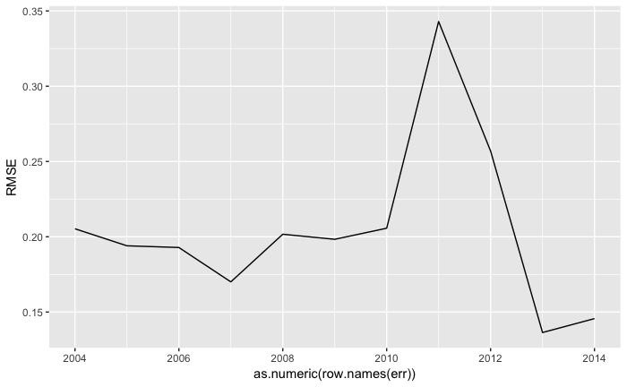

```r
library(ggplot2)
err = data.frame("RMSE" = rep(0, 2014-2004+1), row.names = seq(2004, 2014))
for (y in 2004:2014){
    model = Arima(window(train, start=c(y,1)), order=c(4,1,1), seasonal=c(1,0,0))
    rmse = accuracy(forecast(model,h=12),test)[2,"RMSE"]
    err[as.character(y),] = rmse
}
ggplot(err)+geom_line(aes(x=as.numeric(row.names(err)), y=RMSE))
```

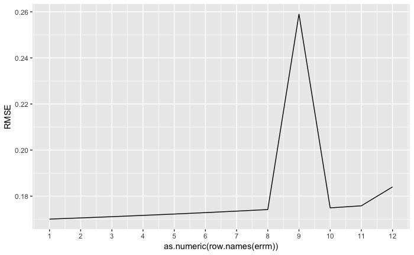

```r
errm = data.frame("RMSE" = rep(0, 12), row.names = seq(1, 12))
for (m in 1:12){
    model = Arima(window(train, start=c(2007,m)), order=c(4,1,1), seasonal=c(1,0,0))
    rmse = accuracy(forecast(model,h=12),test)[2,"RMSE"]
    errm[as.character(m),] = rmse
}
ggplot(errm)+geom_line(aes(x=as.numeric(row.names(errm)), y=RMSE))+scale_x_continuous(breaks=seq(1,12))
```

```r
rollwitme = function(lgas){
    RMSE = rep(0,9)
    for (y in 2004:2007){
        tr = window(lgas, start=c(y,3), end=c(y+8,2))
        te = window(lgas, start=c(y+8,3), end=c(y+9,2))
        model = Arima(tr, order=c(4,1,1), seasonal=c(1,0,0))
        RMSE[y+1-2004] = accuracy(forecast(model,h=12),te)[2,"RMSE"]
    }
    return(RMSE)
}
```

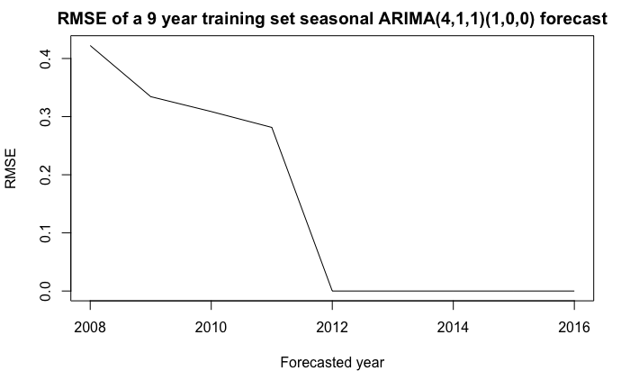

```r
plot(2008:2016, rollwitme(sextreme_cold), type = 'l', main = "RMSE of a 9 year training set seasonal ARIMA(4,1,1)(1,0,0) forecast", ylab = "RMSE", xlab = "Forecasted year")
```

As for snaive :

```r
rollwitme = function(lgas){
    RMSE = rep(0,12)
    for (y in 2004:2015){
        tr = window(lgas, start=c(y,3), end=c(y+1,2))
        te = window(lgas, start=c(y+1,3), end=c(y+2,2))
        pred = snaive(tr, h = 12)
        RMSE[y+1-2004] = accuracy(pred,te)[2,"RMSE"]
    }
    return(RMSE)
}
```

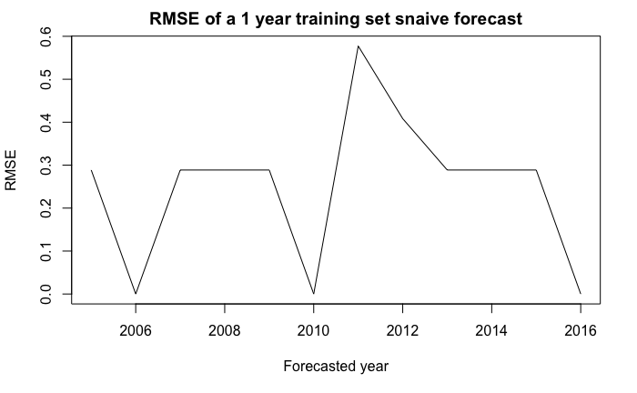

```r
plot(2005:2016, rollwitme(sextreme_cold), type = 'l', main = "RMSE of a 1 year training set snaive forecast", ylab = "RMSE", xlab = "Forecasted year")
```

Creation of the needed forecast : from March 2017 to March 2018 (we will only use from March 2017 to July 2017).

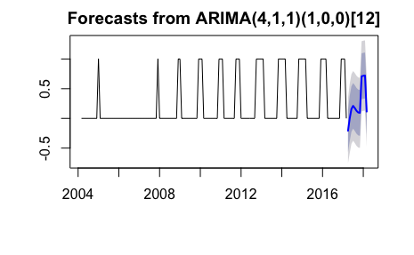

```r
train_final = window(sextreme_cold, start=c(2004,3), end=c(2017,3))
model = Arima(train_final, order=c(4,1,1), seasonal=c(1,0,0))
yearly_forecast = forecast(model,h=12)
plot(yearly_forecast)
```